# assignment

Ieva Gudelytė

2026-04-23

```r
suppressPackageStartupMessages({
  library(epiwraps)
  library(AnnotationHub)
  library(MotifDb)
  library(memes)
  library(universalmotif)
  library(ensembldb)
  library(ggplot2)
  library(motifmatchr)
  library(sechm)
  library(BSgenome.Mmusculus.UCSC.mm10)
  library(limma)
  library(betterChromVAR)
})
```

```
## See system.file("LICENSE", package="MotifDb") for use restrictions.
```

```r
ah <- AnnotationHub(localHub = FALSE)
ensdb <- ah[["AH89211"]] # mouse ensembldb object
```

```
## loading from cache
```

# Part 1

## Downloading the data

```r
download.file("https://ethz-ins.org/content/w7/atac.chr19.bam", "atac.chr19.bam", mode="wb")
download.file("https://ethz-ins.org/content/w7/atac.chr19.bam.bai", "atac.chr19.bam.bai", mode="wb")
```

## Preparing tracks

```r
bam <- "atac.chr19.bam"

# create a track using all fragments, computing the coverage at each position (and force Ensembl naming)
epiwraps::bam2bw(bam, output_bw = "full_cov.bw", paired=TRUE, binWidth=10L, forceSeqlevelsStyle = "Ensembl")
```

```
## `extend` argument ignored.
```

```
## Reading in signal...
```

```
## Writing bigwig...
```

```r
# create a track using all fragments, but computing the number of cuts/insertion sites at each position
bam2bw(bam, output_bw = "full_cuts.bw", paired=TRUE, binWidth=1L, type="ends",
                 trim=4L, extend=3L, forceSeqlevelsStyle = "Ensembl")
```

```
## Reading in signal...
## Writing bigwig...
```

```r
# create a track using only nucleosome-free fragments, computing coverage
bam2bw(bam, output_bw = "NF_cov.bw", paired=TRUE, binWidth=5L, minFragLength=30,
       maxFragLength=120, forceSeqlevelsStyle = "Ensembl")
```

```
## `extend` argument ignored.
```

```
## Reading in signal...
```

```
## Writing bigwig...
```

```r
# create a track using only nucleosome-free fragments, the number of cuts/insertion sites at each position
bam2bw(bam, output_bw = "NF_cuts.bw", paired=TRUE, binWidth=1L, type="ends", minFragLength=30,
       maxFragLength=120, trim=4L, extend=3L, forceSeqlevelsStyle = "Ensembl")
```

```
## Reading in signal...
## Writing bigwig...
```

```r
# create a track using only mono-nucleosome fragments, computing coverage
bam2bw(bam, output_bw = "mono_cov.bw", paired=TRUE, binWidth=10L, minFragLength=140,
       maxFragLength=220, forceSeqlevelsStyle = "Ensembl")
```

```
## `extend` argument ignored.
```

```
## Reading in signal...
```

```
## Writing bigwig...
```

```r
# create a track using only the (10bp) centers of mono-nucleosome fragments
bam2bw(bam, output_bw = "mono_centers.bw", paired=TRUE, binWidth=5L, minFragLength=140, trim=4L,
       maxFragLength=220, type="center", extend=10L, forceSeqlevelsStyle = "Ensembl")
```

```
## Reading in signal...
## Writing bigwig...
```

```r
# create a track using only the (10bp) centers of nucleosome-containing fragments
```

[output not shown]

## Obtaining the sites with a REST motif

```r
# get REST motif
motif <- MotifDb::query(MotifDb, c("REST","Mus"))[[1]]
motif2 <- convert_motifs(motif, class="TFBSTools-PFMatrix")
```

```
## Note: motif [motif] has an empty nsites slot, using 100.
```

```r
genome <- ah[["AH68356"]]
```

```
## loading from cache
```

```r
# get the sequence for chr19:
chr19 <- import(genome)["19"]

# find motif matches across chr19
moi <- motifmatchr::matchMotifs(motif2, chr19, out="positions", p.cutoff=1e-5)[[1]]
# convert to GRanges
moi <- as(setNames(moi,names(chr19)), "GRanges")
```

## Plotting signal around the motif occurences

Here we plot the insertion (i.e. ‘cuts’) profile of nucleosome-free fragments and the centers of nucleosome-containing fragments around the high-confidence motifs of TF REST.

```r
# we prepare the list of tracks
tracks <- list.files(pattern="bw$")
names(tracks) <- gsub("\\.bw","",basename(tracks))

# extract signals around the motif occurences
# we zoom in to 300bp around the motif centers, in windows of 5bp
sm <- signal2Matrix(tracks[c("NF_cuts", "mono_centers")] , moi, w=5, extend=300)
```

```
## Reading NF_cuts.bw
```

```
## Reading mono_centers.bw
```

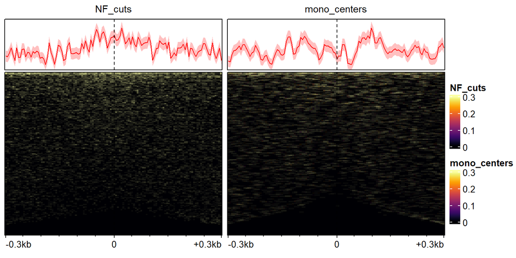

```r
# plot the signals:
plotEnrichedHeatmaps(sm, trim=0.95, multiScale = TRUE, axis_name = "0")
```

Here we overlay the two signals, aggregated across regions:

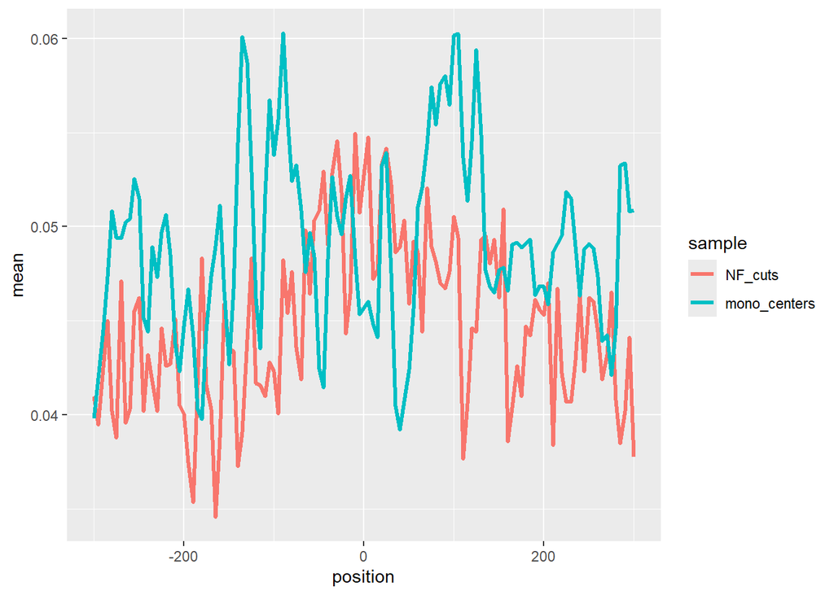

```r
d <- meltSignals(sm[,c("NF_cuts", "mono_centers")])
ggplot(d, aes(position, mean, colour=sample)) + geom_line(size=1.2)
```

# Part 2

## Downloading the data

We will use mouse hippocampus ATAC-seq data:

```r
download.file("https://ethz-ins.org/content/mouse_mm38_hippocampus.peakCounts.SE.rds", "peakCounts.rds", mode="wb")
```

```r
se <- readRDS("peakCounts.rds")
```

The object contains fragment counts in peaks across control and stressed samples.

## Region annotation

```r
resize(se, width=300, fix="center")
```

```
## class: RangedSummarizedExperiment
## dim: 20660 12
## metadata(0):
## assays(1): counts
## rownames: NULL
## rowData names(0):
## colnames(12): Control_female_GSM6041841.bam
##   Control_female_GSM6041842.bam ... FSS_male_GSM6041857.bam
##   FSS_male_GSM6041858.bam
## colData names(1): depth
```

Here we determine the GC content of the regions.

```r
# we restrict the regions to standard chromosomes and change the seq level style to match the genome
se <- GenomeInfoDb::keepStandardChromosomes(se, pruning.mode = "coarse")
seqlevelsStyle(se) <- "UCSC"
se <- addGCBias(se, genome=BSgenome.Mmusculus.UCSC.mm10)
```

Here we determine which motif matches each region. For the annotation, we first need to get a list of motifs, and then scan the regions for matches to them.

```r
motifs <- query(MotifDb, "HOCOMOCOv13")
```

Here we convert the motifs to a format that `motifmatchr` accepts.

```r
motifs <- do.call(TFBSTools::PWMatrixList, convert_motifs(motifs, class="TFBSTools-PWMatrix"))
names(motifs) <- make.unique(sapply(motifs, \(x) gsub("\\..+","",x@name)))
```

We then scan regions for matches of the motifs:

```r
matches <- motifmatchr::matchMotifs(motifs, se, genome=BSgenome.Mmusculus.UCSC.mm10)
matches
```

```
## class: RangedSummarizedExperiment
## dim: 20660 1358
## metadata(0):
## assays(1): motifMatches
## rownames: NULL
## rowData names(1): bias
## colnames(1358): LEUTX FBXL19 ... ZSCA1 ZSCA4
## colData names(1): name
```

The output is a SummarizedExperiment object, where columns are the motifs and the rows are the regions, and the assay is a logical sparse matrix.

```r
assay(matches)[1:10,1:20]
```

```
## 10 x 20 sparse Matrix of class "lgCMatrix"
```

```
##   [[ suppressing 20 column names 'LEUTX', 'FBXL19', 'ZBED5' ... ]]
```

```
##
##  [1,] . . . . . . . . . . . . . . . . . . . .
##  [2,] . . . . . . . . . . . | . . . . | . | .
##  [3,] . . . . . . . . . . . . . . . . . . . .
##  [4,] . . . . . . . . . . . . . . . . . . . .
##  [5,] . . . . . . . . . . . . . . . . . . . .
##  [6,] . . . . . . . . . . . . . . . . . . . .
##  [7,] . . . . . . . . . . . . . . . . . . . .
##  [8,] . . . . . . . . . . . . . . . | . . . .
##  [9,] . . . . . . . . . . . . . . . . . . . .
## [10,] . . . . . . . . . . . . . . . . . . . .
```

## Getting motif deviations

(Motif deviation = how much accessibility around a motif differs from expectation)

```r
dev <- betterChromVAR(se, matches)
dev
```

```
## class: SummarizedExperiment
## dim: 1358 12
## metadata(0):
## assays(2): deviations z
## rownames(1358): LEUTX FBXL19 ... ZSCA1 ZSCA4
## rowData names(6): name N ... var.pval var.adjPval
## colnames(12): Control_female_GSM6041841.bam
##   Control_female_GSM6041842.bam ... FSS_male_GSM6041857.bam
##   FSS_male_GSM6041858.bam
## colData names(1): depth
```

The output is a SummarizedExperiment object, where columns are the samples and the rows are the motifs. The values represent the relative accessibility of each motif in each sample. The motif deviations can be used to perform differential analysis.

## Differential analysis

Here we identify motifs that change in accessibility between males and females.

```r
dev$group <- ifelse(grepl("female", colnames(dev)), "Female", "Male")
design <- model.matrix(~group, data=as.data.frame(colData(dev)))
fit <- eBayes(lmFit(assay(dev, "z"), design))
res <- as.data.frame(topTable(fit, number = Inf))
```

```
## Removing intercept from test coefficients
```

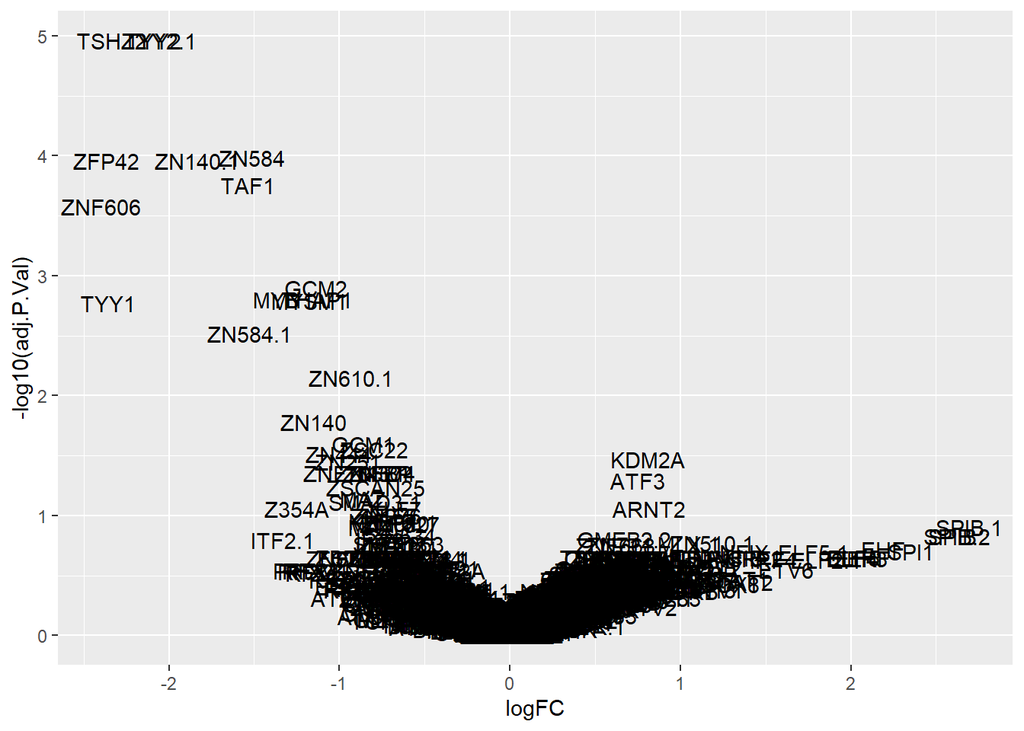

```r
res$motif <- row.names(res)
ggplot(res, aes(logFC, -log10(adj.P.Val), label=motif)) + geom_text()
```

Plotting a heatmap of the deviations for the top few candidate motifs.

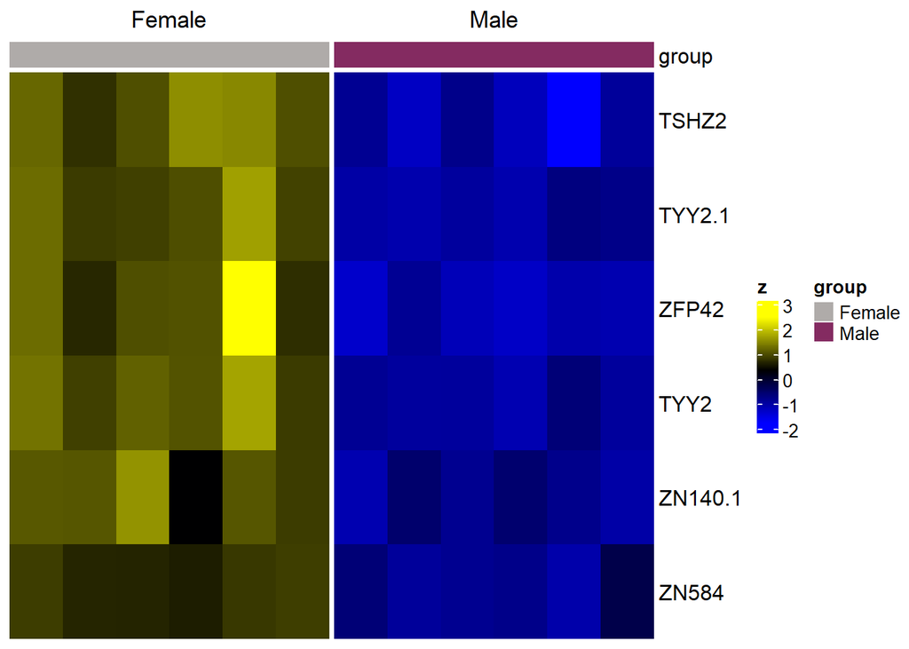

```r
sechm(dev, head(row.names(res)), gaps_at="group", assayName = "z")
```